# Class 8 Machine Learning 1

Alanna Koehler

10/25/2019

## K-means example

Generate a simple dataset for clustering:

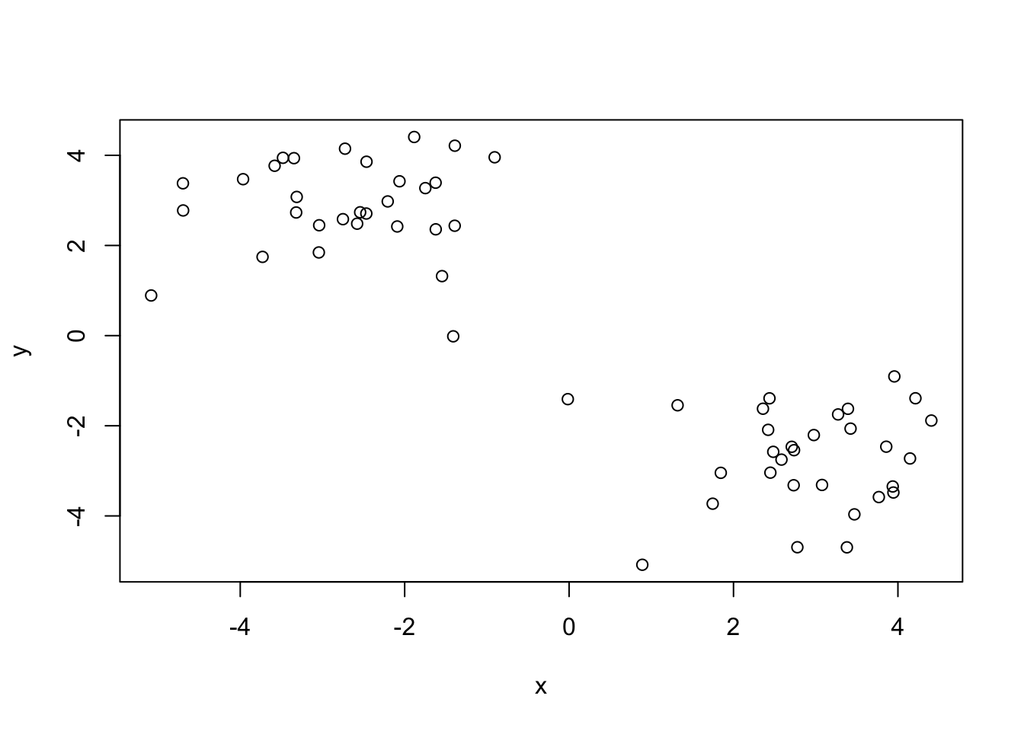

```r
tmp <- c(rnorm(30,-3), rnorm(30,3)) #Give you 30 points centered at -3 and 30 points centered at 3.
x <- cbind(x=tmp, y=rev(tmp)) #column-wise binds our vector into 2 columns
plot(x)
```

Use the kmeans() function setting k to 2 and nstart=20

```r
k <- kmeans(x, centers = 2, nstart = 20)
```

This gives us a list of 9 elements in our global environment. Print the results

```r
k
```

```
## K-means clustering with 2 clusters of sizes 30, 30
##
## Cluster means:
##           x         y
## 1 -2.689978  2.889918
## 2  2.889918 -2.689978
##
## Clustering vector:
##  [1] 1 1 1 1 1 1 1 1 1 1 1 1 1 1 1 1 1 1 1 1 1 1 1 1 1 1 1 1 1 1 2 2 2 2 2
## [36] 2 2 2 2 2 2 2 2 2 2 2 2 2 2 2 2 2 2 2 2 2 2 2 2 2
##
## Within cluster sum of squares by cluster:
## [1] 64.36344 64.36344
##  (between_SS / total_SS =  87.9 %)
##
## Available components:
##
## [1] "cluster"      "centers"      "totss"        "withinss"
## [5] "tot.withinss" "betweenss"    "size"         "iter"
## [9] "ifault"
```

The clustering vector tells you in which cluster each element lies.

Inspect the results: Q. How many points are in each cluster?

```r
k$size
```

```
## [1] 30 30
```

Q. What ‘component’ of your result object details - cluster size?

```r
k$cluster
```

```
##  [1] 1 1 1 1 1 1 1 1 1 1 1 1 1 1 1 1 1 1 1 1 1 1 1 1 1 1 1 1 1 1 2 2 2 2 2
## [36] 2 2 2 2 2 2 2 2 2 2 2 2 2 2 2 2 2 2 2 2 2 2 2 2 2
```

- cluster assignment/membership?

```r
table(k$cluster)
```

```
##
##  1  2
## 30 30
```

- cluster center?

```r
k$centers
```

```
##           x         y
## 1 -2.689978  2.889918
## 2  2.889918 -2.689978
```

Plot x colored by the kmeans cluster assignment and add cluster centers as blue points

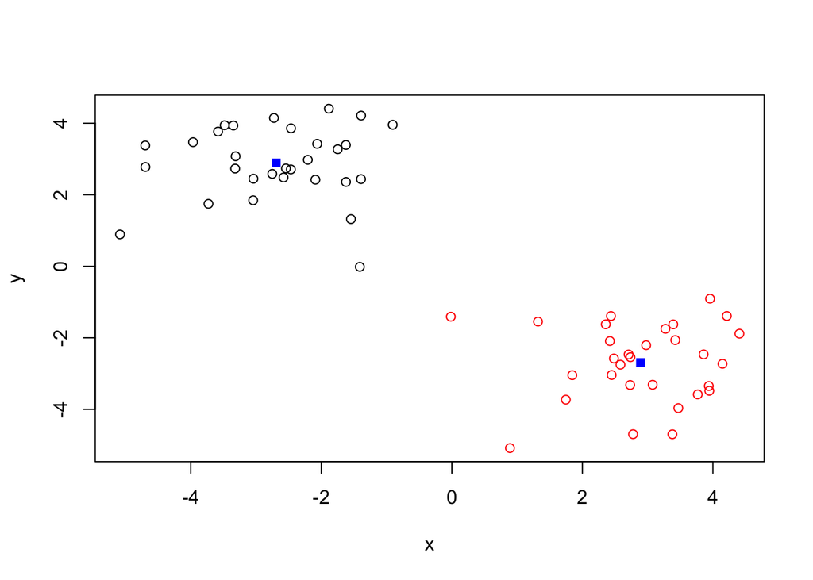

```r
plot(x, col = k$cluster)
points(k$centers, col = "blue", pch = 15)
```

## Hierarchical clustering example

First we need to calculate point (dis)similarity as the Euclidean distance between observations.

```r
dist_matrix <- dist(x)
```

The hclust() function returns a hierarchical clustering model

```r
hc <- hclust(d = dist_matrix)
```

The print method is not so useful here

```r
hc
```

```
##
## Call:
## hclust(d = dist_matrix)
##
## Cluster method   : complete
## Distance         : euclidean
## Number of objects: 60
```

Plot results in a dendrogram

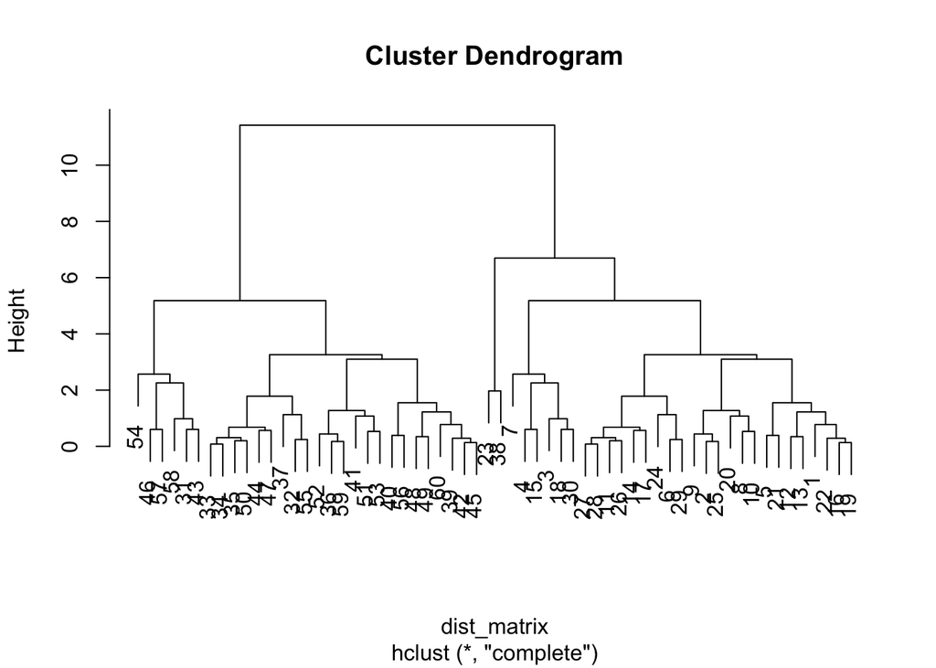

```r
plot(hc)
```

You then have to cut this tree in a position you like. First you can generate an abline:

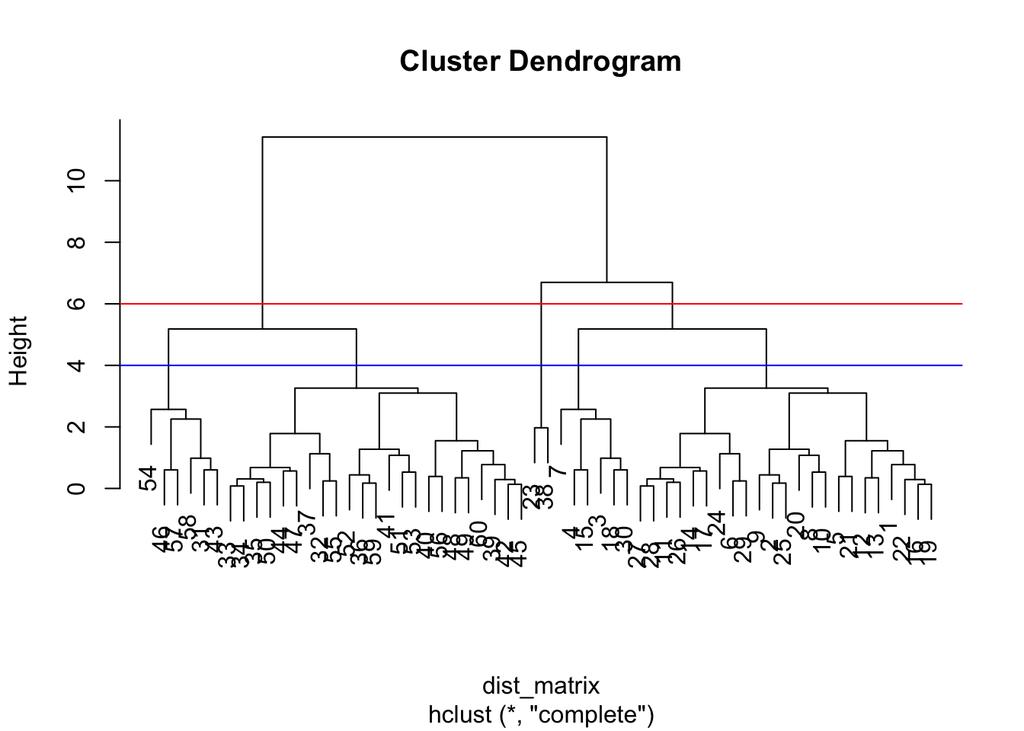

```r
plot(hc)
abline(h=6, col="red")
abline(h=4, col="blue")
```

Cut the tree at a certain height and assign each element to a cluster.

```r
cutree(hc, h=6)
```

```
##  [1] 1 1 1 1 1 1 1 1 1 1 1 1 1 1 1 1 1 1 1 1 1 1 2 1 1 1 1 1 1 1 3 3 3 3 3
## [36] 3 3 2 3 3 3 3 3 3 3 3 3 3 3 3 3 3 3 3 3 3 3 3 3 3
```

```r
cutree(hc, h=4)
```

```
##  [1] 1 1 2 2 1 1 2 1 1 1 1 1 1 1 2 1 1 2 1 1 1 1 3 1 1 1 1 1 1 2 4 5 5 5 5
## [36] 5 5 3 5 5 5 5 4 5 5 4 5 5 5 5 5 5 5 4 5 5 4 4 5 5
```

You can quantify how many elements are in each cut group by making a table.

```r
grps <- cutree(hc, h=6)
table(grps)
```

```
## grps
##  1  2  3
## 29  2 29
```

Once you have defined the groups, you can then color your clusters based on those groups.

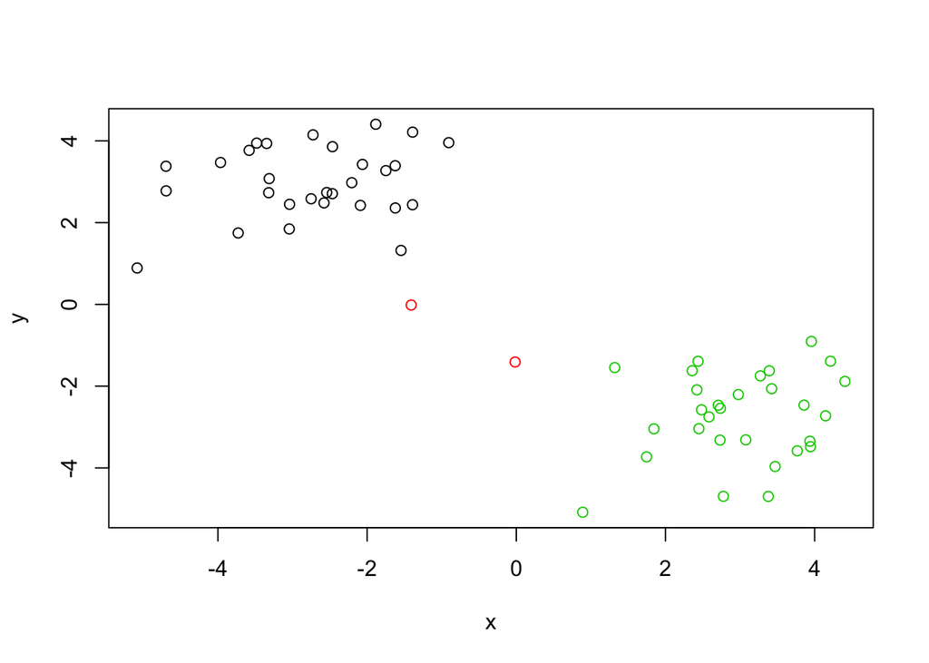

```r
plot(x, col = grps)
```

You can also cut the tree to yield a given k groups/clusters

```r
cutree(hc, k=2)
```

```
##  [1] 1 1 1 1 1 1 1 1 1 1 1 1 1 1 1 1 1 1 1 1 1 1 1 1 1 1 1 1 1 1 2 2 2 2 2
## [36] 2 2 1 2 2 2 2 2 2 2 2 2 2 2 2 2 2 2 2 2 2 2 2 2 2
```

## Using different hierarchical clustering methods

Step 1. Generate some example data for clustering

```r
x <- rbind(
 matrix(rnorm(100, mean=0, sd = 0.3), ncol = 2), # c1
 matrix(rnorm(100, mean = 1, sd = 0.3), ncol = 2), # c2
 matrix(c(rnorm(50, mean = 1, sd = 0.3), # c3
 rnorm(50, mean = 0, sd = 0.3)), ncol = 2))
colnames(x) <- c("x", "y")
```

Step 2. Plot the data without clustering

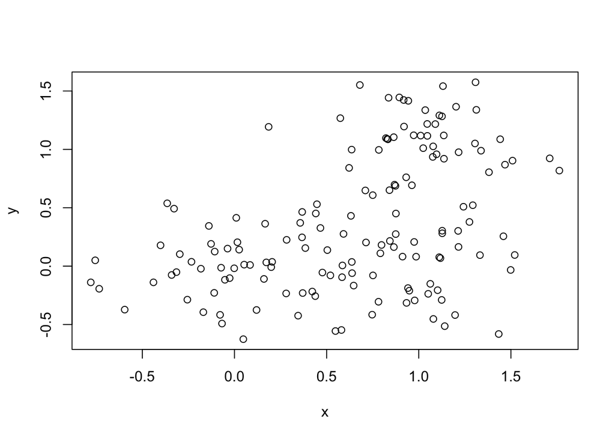

```r
plot(x)
```

Step 3. Generate colors for known clusters (just so we can compare to hclust results).

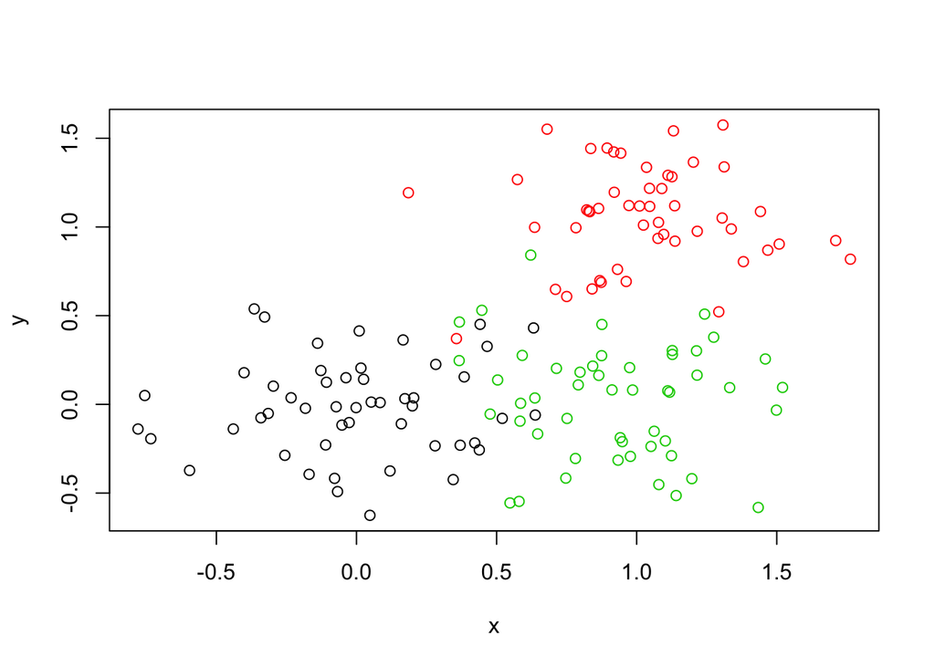

```r
col <- as.factor( rep(c("c1","c2","c3"), each=50) )
plot(x, col=col)
```

Answer questions Use the dist(), hclust(), plot() and cutree() functions to return 2 and 3 clusters. How does this compare to your known col groups.

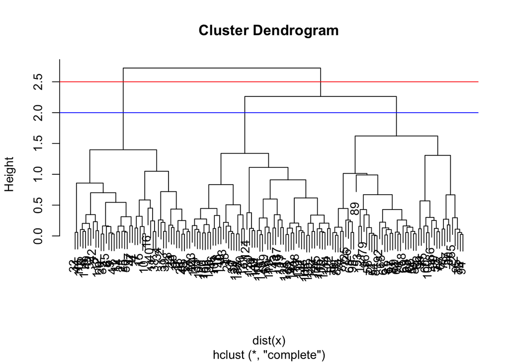

```r
hc2 <- hclust(dist(x))
plot(hc2)
abline(h=2.5, col = "red")
abline(h=2, col = "blue")
```

```r
grps2 <- cutree(hc2, k=2)
table(grps2)
```

```
## grps2
##   1   2
##  45 105
```

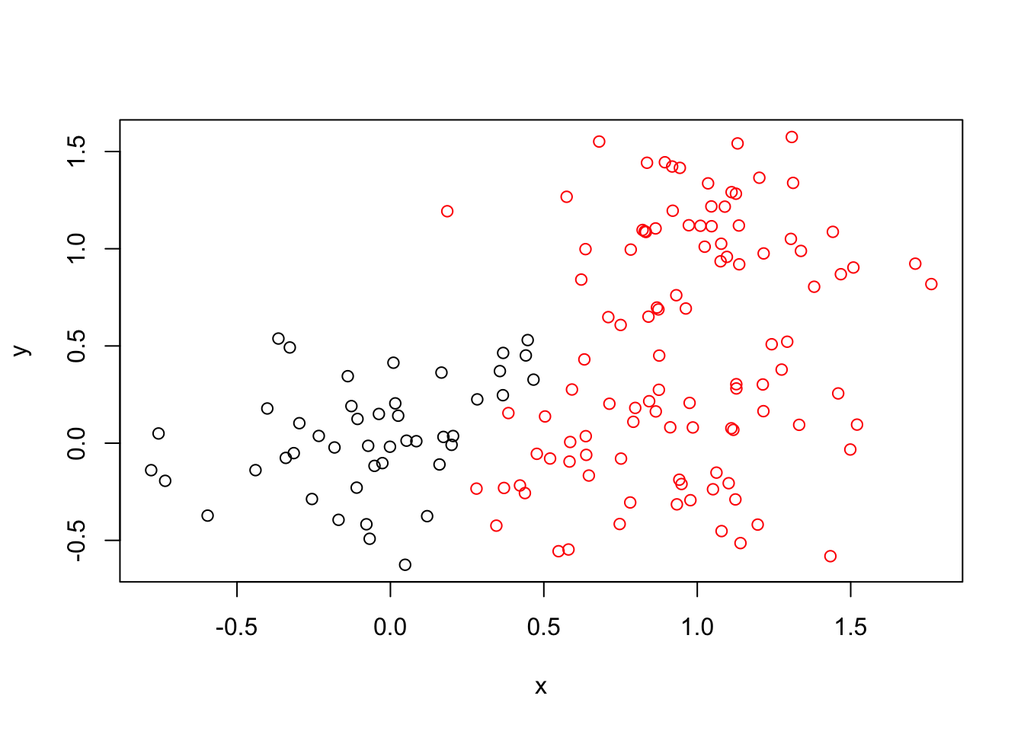

```r
plot(x, col = grps2)
```

```r
table(col, grps2)
```

```
##     grps2
## col   1  2
##   c1 41  9
##   c2  1 49
##   c3  3 47
```

```r
grps3 <- cutree(hc2, k=3)
table(grps3)
```

```
## grps3
##  1  2  3
## 45 54 51
```

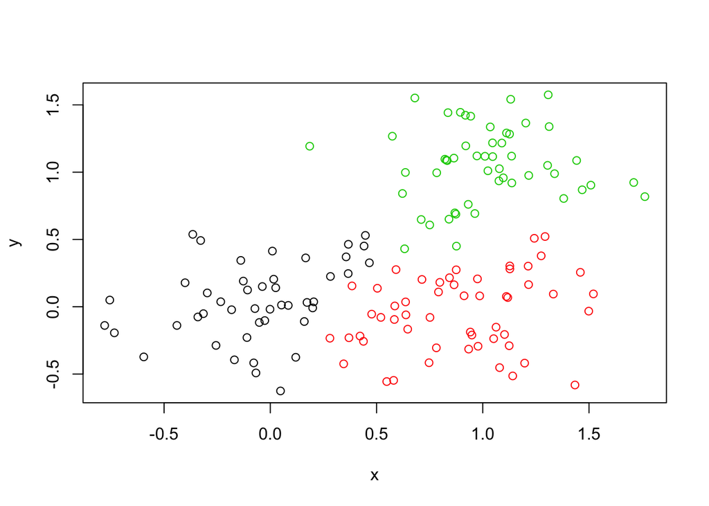

```r
plot(x, col = grps3)
```

```r
table(col, grps3)
```

```
##     grps3
## col   1  2  3
##   c1 41  8  1
##   c2  1  1 48
##   c3  3 45  2
```

## Principle Component Analysis

Plot example data

```r
mydata <- read.csv("https://tinyurl.com/expression-CSV",
 row.names=1)
head(mydata)
```

|  | wt1 | wt2 | wt3 | wt4 | wt5 | ko1 | ko2 | ko3 | ko4 | ko5 |
| --- | --- | --- | --- | --- | --- | --- | --- | --- | --- | --- |
| gene1 | 439 | 458 | 408 | 429 | 420 | 90 | 88 | 86 | 90 | 93 |
| gene2 | 219 | 200 | 204 | 210 | 187 | 427 | 423 | 434 | 433 | 426 |
| gene3 | 1006 | 989 | 1030 | 1017 | 973 | 252 | 237 | 238 | 226 | 210 |
| gene4 | 783 | 792 | 829 | 856 | 760 | 849 | 856 | 835 | 885 | 894 |
| gene5 | 181 | 249 | 204 | 244 | 225 | 277 | 305 | 272 | 270 | 279 |
| gene6 | 460 | 502 | 491 | 491 | 493 | 612 | 594 | 577 | 618 | 638 |

Note that samples are columns and genes are rows.

Now define your PCA components and look at the attributes

```r
pca <- prcomp(t(mydata), scale=TRUE) #Need to transpose with t() bc prcomp expects samples to be rows and genes to be columns
attributes(pca)
```

```
## $names
## [1] "sdev"     "rotation" "center"   "scale"    "x"
##
## $class
## [1] "prcomp"
```

Make a basic PC1 vs PC2 plot.

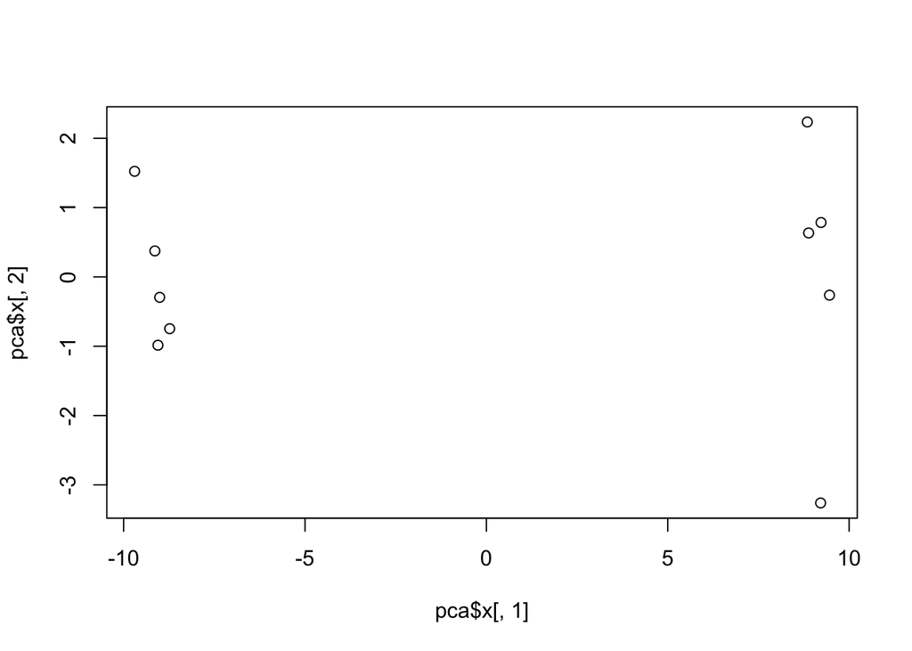

```r
plot(pca$x[,1], pca$x[,2])
```

```r
summary(pca)
```

```
## Importance of components:
##                           PC1    PC2     PC3     PC4     PC5     PC6
## Standard deviation     9.6237 1.5198 1.05787 1.05203 0.88062 0.82545
## Proportion of Variance 0.9262 0.0231 0.01119 0.01107 0.00775 0.00681
## Cumulative Proportion  0.9262 0.9493 0.96045 0.97152 0.97928 0.98609
##                            PC7     PC8     PC9      PC10
## Standard deviation     0.80111 0.62065 0.60342 3.348e-15
## Proportion of Variance 0.00642 0.00385 0.00364 0.000e+00
## Cumulative Proportion  0.99251 0.99636 1.00000 1.000e+00
```

PC1 captures 92.6% of the variance.

Calculate variance captured by each PC.

```r
pca.var <- pca$sdev^2
pca.var
```

```
##  [1] 9.261625e+01 2.309940e+00 1.119081e+00 1.106773e+00 7.754851e-01
##  [6] 6.813705e-01 6.417798e-01 3.852003e-01 3.641185e-01 1.121154e-29
```

You can also look at percent variance.

```r
pca.var <- pca$sdev^2
pca.var.per <- round(pca.var/sum(pca.var)*100, 1)
pca.var.per
```

```
##  [1] 92.6  2.3  1.1  1.1  0.8  0.7  0.6  0.4  0.4  0.0
```

Make a scree plot.

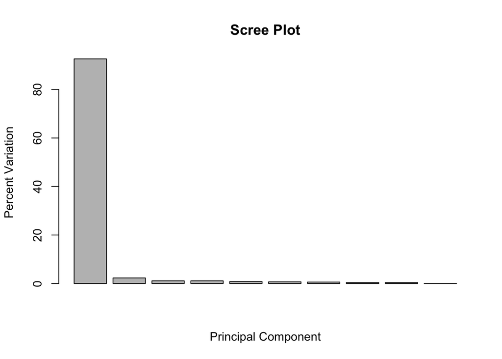

```r
barplot(pca.var.per, main="Scree Plot",
 xlab="Principal Component", ylab="Percent Variation")
```

Add color to your PCA plot.

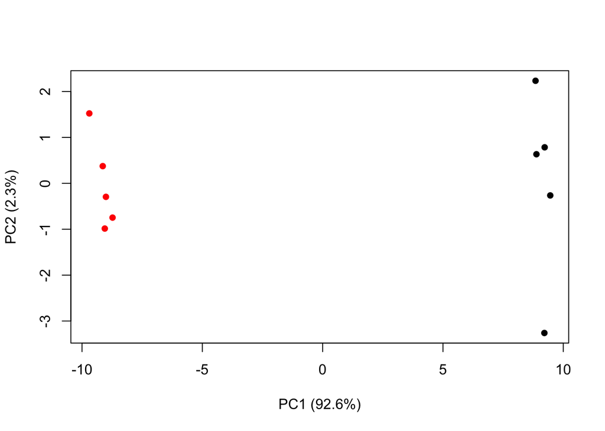

```r
colvec <- as.factor( substr( colnames(mydata), 1, 2) )
plot(pca$x[,1], pca$x[,2], col=colvec, pch=16,
 xlab=paste0("PC1 (", pca.var.per[1], "%)"),
 ylab=paste0("PC2 (", pca.var.per[2], "%)"))
```